# Bears

Holden Katin-Bayer

Fall 2026

## make a simple regression model

```r
bears <- read.csv(file="BEARS.csv",header = TRUE)
#adjust factors to be factors
bears$SEX<- as.factor(bears$SEX)
bears$MONTH<- as.factor(bears$MONTH)
```

## Model LENGTH ~ NECK this is an example

Compare all models that predict LENGTH other than NECK.  
Then order them from worst to best by its value of Adjusted-Rsquared (bigger is better), or by RSE (residual standard error) where smaller is better.

We, the master RStudio statisticians of this class are trying to organize bear size in a ranking of 4 different models comparing different bodily features. The data comes from the bears data package.

LENGTH is numerical.

HEADLEN is numerical.

HEADWTH is numerical.

CHEST is numerical.

WEIGHT is numerical.

## Model LENGTH ~ HEADLEN

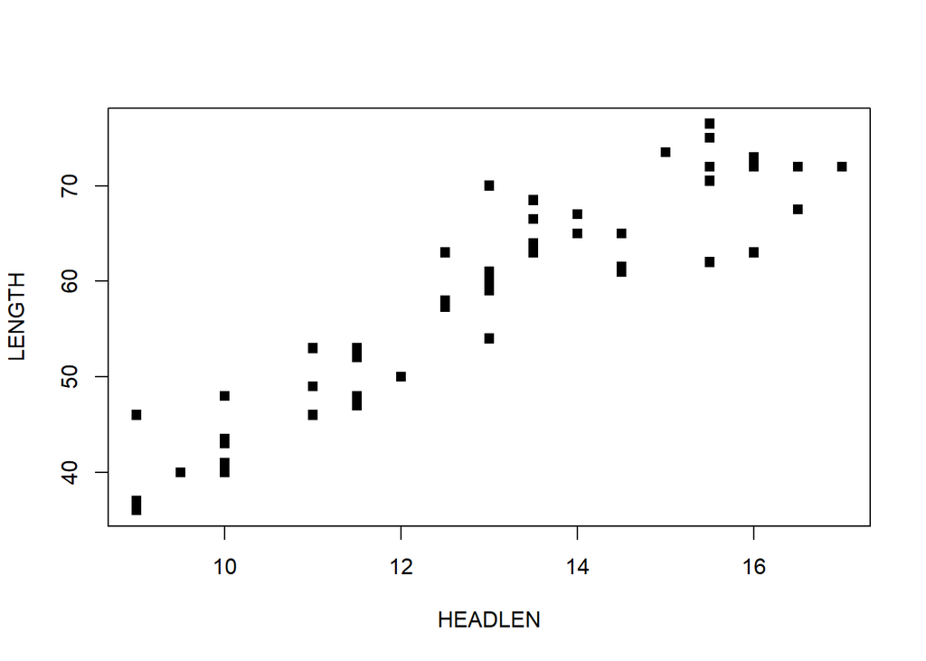

```r
plot(LENGTH~HEADLEN,data=bears, pch=15)
```

The plot suggests that as LENGTH increases, HEADLEN increases in a linear fashion.

```r
model.1 <- lm(LENGTH~HEADLEN,data=bears)
summary.lm(model.1)
```

```
##
## Call:
## lm(formula = LENGTH ~ HEADLEN, data = bears)
##
## Residuals:
##     Min      1Q  Median      3Q     Max
## -9.6037 -3.6005  0.2942  2.7500 11.1708
##
## Coefficients:
##             Estimate Std. Error t value Pr(>|t|)
## (Intercept)  -0.8600     3.5618  -0.241     0.81
## HEADLEN       4.5915     0.2713  16.922   <2e-16 ***
## ---
## Signif. codes:  0 '***' 0.001 '**' 0.01 '*' 0.05 '.' 0.1 ' ' 1
##
## Residual standard error: 4.235 on 52 degrees of freedom
## Multiple R-squared:  0.8463, Adjusted R-squared:  0.8434
## F-statistic: 286.3 on 1 and 52 DF,  p-value: < 2.2e-16
```

The residual standard error is 4.235. Or 4.2 rounded. The adjusted R-squared is 0.8434. Or 0.84 rounded.

## Model LENGTH ~ HeadWTH

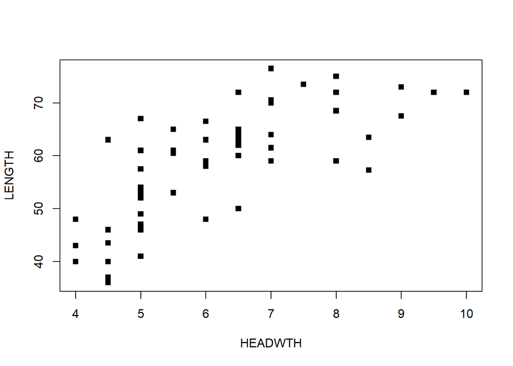

```r
plot(LENGTH~HEADWTH,data=bears, pch=15)
```

The plot suggests that as LENGTH increases, HEADWTH increases, in a moderately linear fashion.

```r
model.2 <- lm(LENGTH~HEADWTH,data=bears)
summary.lm(model.2)
```

```
##
## Call:
## lm(formula = LENGTH ~ HEADWTH, data = bears)
##
## Residuals:
##      Min       1Q   Median       3Q      Max
## -13.7987  -5.6379   0.4412   5.3212  14.5993
##
## Coefficients:
##             Estimate Std. Error t value Pr(>|t|)
## (Intercept)  26.3804     4.2374   6.226 8.46e-08 ***
## HEADWTH       5.2041     0.6649   7.827 2.39e-10 ***
## ---
## Signif. codes:  0 '***' 0.001 '**' 0.01 '*' 0.05 '.' 0.1 ' ' 1
##
## Residual standard error: 7.32 on 52 degrees of freedom
## Multiple R-squared:  0.5409, Adjusted R-squared:  0.5321
## F-statistic: 61.26 on 1 and 52 DF,  p-value: 2.392e-10
```

The residual standard error is 7.32. The adjusted R-Squared is 0.5321. Or 0.53 rounded.

## Model LENGTH ~ CHEST

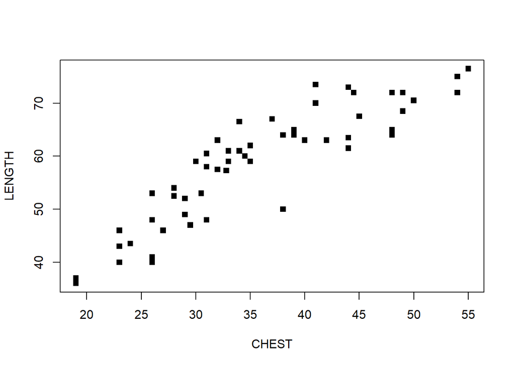

```r
plot(LENGTH~CHEST,data=bears, pch=15)
```

The plot suggests that as LENGTH increases, CHEST increases in a linear fashion.

```r
model.3 <- lm(LENGTH~CHEST,data=bears)
summary.lm(model.3)
```

```
##
## Call:
## lm(formula = LENGTH ~ CHEST, data = bears)
##
## Residuals:
##      Min       1Q   Median       3Q      Max
## -10.9950  -3.6672   0.0668   3.8389   9.5757
##
## Coefficients:
##             Estimate Std. Error t value Pr(>|t|)
## (Intercept) 22.32388    2.67328   8.351 3.57e-11 ***
## CHEST        1.01766    0.07255  14.027  < 2e-16 ***
## ---
## Signif. codes:  0 '***' 0.001 '**' 0.01 '*' 0.05 '.' 0.1 ' ' 1
##
## Residual standard error: 4.939 on 52 degrees of freedom
## Multiple R-squared:  0.791,  Adjusted R-squared:  0.7869
## F-statistic: 196.7 on 1 and 52 DF,  p-value: < 2.2e-16
```

## Model LENGTH ~ WEIGHT

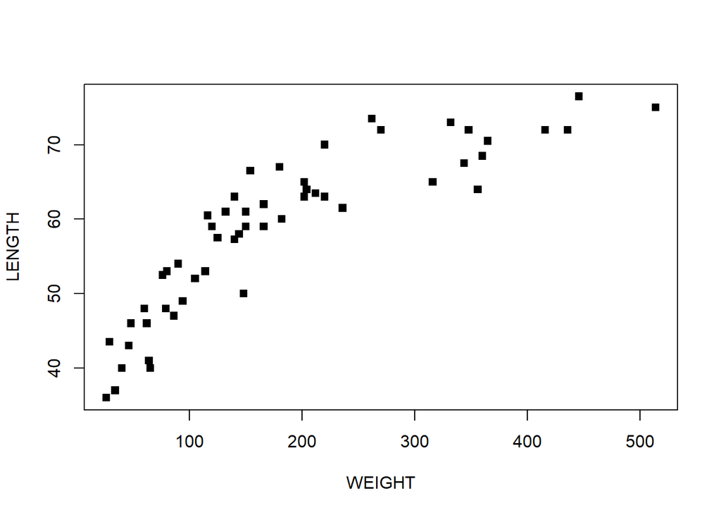

```r
plot(LENGTH~WEIGHT,data=bears, pch=15)
```

The plot suggests that as LENGTH increases, WEIGHT increases in a nonlinear moderate curve.

```r
model.4 <- lm(LENGTH~WEIGHT,data=bears)
summary.lm(model.4)
```

```
##
## Call:
## lm(formula = LENGTH ~ WEIGHT, data = bears)
##
## Residuals:
##     Min      1Q  Median      3Q     Max
## -10.702  -3.534   1.148   3.655  10.077
##
## Coefficients:
##              Estimate Std. Error t value Pr(>|t|)
## (Intercept) 44.727632   1.342207   33.32   <2e-16 ***
## WEIGHT       0.075942   0.006126   12.40   <2e-16 ***
## ---
## Signif. codes:  0 '***' 0.001 '**' 0.01 '*' 0.05 '.' 0.1 ' ' 1
##
## Residual standard error: 5.432 on 52 degrees of freedom
## Multiple R-squared:  0.7472, Adjusted R-squared:  0.7423
## F-statistic: 153.7 on 1 and 52 DF,  p-value: < 2.2e-16
```

The residual standard error is 5.432. Or 5.4 rounded. The adjusted r-squared is 0.7423. or 0.74 rounded.

# CONCLUSIONS

To arrange the four models in a regression, we can use residual standard error which is numbered large to small. Adjusted R-squared is small to large.

Adjusted R-Squared Model 2 (0.53) - Model 4 (0.74) - Model 3 (0.8) - Model 1 (0.84)